# Importing Data

# Feature selection

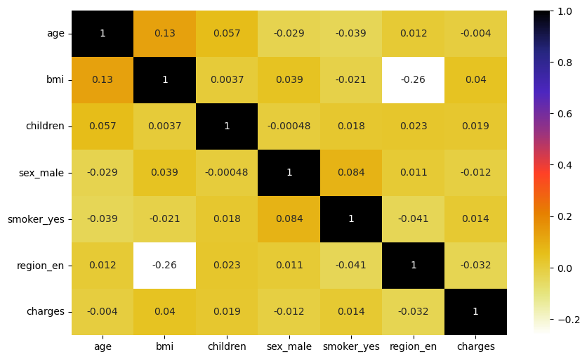

```python
#1 Correlation Method
import seaborn as sns
import matplotlib.pyplot as plt
%matplotlib inline
# Concatenate X and y into a single DataFrame
data = pd.concat([X_train_norm,pd.Series(y_train_fit, name='charges')], axis=1)
# Calculate the correlation matrix
correlation_matrix = data.corr()
plt.figure(figsize=(10,6))
sns.heatmap(correlation_matrix, cmap=plt.cm.CMRmap_r,annot=True)
plt.show()
```

# Model building

```python
print(X_train_norm.shape)
print(y_train_fit.shape)
```

```
(1069, 6)
(1069,)
```

```python
from sklearn.linear_model import LinearRegression
LR = LinearRegression()
LR.fit(X_train_norm,y_train_fit)
```

```
LinearRegression()
```

```python
print("intercept",LR.intercept_)
print("LR_model_coef",LR.coef_)
```

```
intercept 9.407576448775357
LR_model_coef [ 2.4060536   0.70083001  0.74927679 -0.11350176  2.4552215   0.20273781]
```

```python
# one hot encoding
dummies=pd.get_dummies(X_test[["sex","smoker"]],drop_first=True)
X_test=pd.concat([X_test,dummies],axis="columns")
X_test.head()
```

|  | age | sex | bmi | children | smoker | region | sex_male | smoker_yes |
| --- | --- | --- | --- | --- | --- | --- | --- | --- |
| 900 | 49 | male | 22.515 | 0 | no | northeast | 1 | 0 |
| 1064 | 29 | female | 25.600 | 4 | no | southwest | 0 | 0 |
| 1256 | 51 | female | 36.385 | 3 | no | northwest | 0 | 0 |
| 298 | 31 | male | 34.390 | 3 | yes | northwest | 1 | 1 |
| 237 | 31 | male | 38.390 | 2 | no | southeast | 1 | 0 |

```python
ord_data={"southeast":0,"southwest":1,"northwest":2,"northeast":3}
X_test["region_en"]=X_test["region"].map(ord_data)
X_test.head()
```

|  | age | sex | bmi | children | smoker | region | sex_male | smoker_yes | region_en |
| --- | --- | --- | --- | --- | --- | --- | --- | --- | --- |
| 900 | 49 | male | 22.515 | 0 | no | northeast | 1 | 0 | 3 |
| 1064 | 29 | female | 25.600 | 4 | no | southwest | 0 | 0 | 1 |
| 1256 | 51 | female | 36.385 | 3 | no | northwest | 0 | 0 | 2 |
| 298 | 31 | male | 34.390 | 3 | yes | northwest | 1 | 1 | 2 |
| 237 | 31 | male | 38.390 | 2 | no | southeast | 1 | 0 | 0 |

```python
X_test=X_test.drop(columns=["sex","smoker","region"])
X_test.head()
```

|  | age | bmi | children | sex_male | smoker_yes | region_en |
| --- | --- | --- | --- | --- | --- | --- |
| 900 | 49 | 22.515 | 0 | 1 | 0 | 3 |
| 1064 | 29 | 25.600 | 4 | 0 | 0 | 1 |
| 1256 | 51 | 36.385 | 3 | 0 | 0 | 2 |
| 298 | 31 | 34.390 | 3 | 1 | 1 | 2 |
| 237 | 31 | 38.390 | 2 | 1 | 0 | 0 |

```python
# Normlization
#from sklearn.preprocessing import MinMaxScaler
#norm = MinMaxScaler().fit(X_train)
X_test_norm=pd.DataFrame(norm.transform(X_test),index=X_test.index, columns=X_test.columns)
X_test_norm.head()
```

|  | age | bmi | children | sex_male | smoker_yes | region_en |
| --- | --- | --- | --- | --- | --- | --- |
| 900 | 0.673913 | 0.206262 | 0.0 | 1.0 | 0.0 | 1.000000 |
| 1064 | 0.239130 | 0.303335 | 0.8 | 0.0 | 0.0 | 0.333333 |
| 1256 | 0.717391 | 0.642700 | 0.6 | 0.0 | 0.0 | 0.666667 |
| 298 | 0.282609 | 0.579924 | 0.6 | 1.0 | 1.0 | 0.666667 |
| 237 | 0.282609 | 0.705790 | 0.4 | 1.0 | 0.0 | 0.000000 |

```python
# box cox power transformation
from scipy import stats
y_test_fit = stats.boxcox(y_test,y_lam)
print("y_test_fit-",y_test_fit)
print("y_lam-",y_lam)
```

```
y_test_fit- 900     11.464782
1064    10.811799
1256    11.899433
298     13.903000
237     10.435418
          ...
534     12.203609
542     12.210116
760     10.241051
1284    14.246019
1285    11.436667
Name: charges, Length: 268, dtype: float64
y_lam- 0.049801243175792737
```

```python
y_LRpred_fit = LR.predict(X_test_norm)
y_LRpred_fit
```

```
array([11.26283786, 10.86252436, 12.1688063 , 13.42042095, 10.76839574,
       11.69048874, 13.08348233,  9.86829603, 11.2990638 , 11.78099915,
       11.90500162, 13.91424123, 13.22383508, 12.34264625, 11.28735187,
       11.354563  ,  9.99189577, 13.26494183, 10.2504955 , 10.43336869,
        9.88796291, 13.30945259, 11.91800218, 13.33727504, 13.21410757,
       10.38903078, 13.9561437 , 14.38507193, 11.70845929, 12.09906269,
       10.62338968, 11.58323577,  9.6062368 , 11.91052176, 14.43934909,
       11.7533315 , 10.55548224, 10.70795689, 13.68892874, 11.28860149,
       10.34537934, 13.76296896, 13.94777159, 11.73308843, 11.39498974,
       10.21520793, 10.14663225, 11.24006143, 10.43561965, 11.05342193,
       10.60611773, 11.18392106, 13.72833818,  9.78173849, 11.35421955,
       11.27856279, 11.63252881, 10.2032834 , 13.12015419, 11.25459953,
       12.19102931, 10.84908455, 11.96860184,  9.72097665, 12.33689949,
       11.91250728, 11.15786637, 13.38561546, 12.1280779 , 12.52251046,
       11.37349723,  9.92246809, 11.02567399,  9.93594108, 11.7191304 ,
        9.58567996, 12.21591296, 10.81478804, 11.36424259, 11.972278  ,
       10.55354802, 12.61423866, 12.15663731, 11.32814005, 14.67906287,
       12.04131346, 10.33397787,  9.73965473, 10.1419315 ,  9.92167456,
       12.31867352, 13.24488309, 10.81790413,  9.85244609,  9.81282122,
       14.18287046, 11.68732817, 11.28132415,  9.89605264, 11.38684639,
       12.17821618, 12.24296786, 13.99594991, 12.09707759, 13.73685979,
        9.60933326, 13.40423801, 12.78800526, 12.16532323, 10.64636843,
       11.02835174, 11.88216458, 10.9783464 , 11.29279135, 10.08999301,
       10.04675349,  9.96068005,  9.67712746, 10.1278659 , 11.5482219 ,
       14.22239298, 10.7066786 , 11.29123472, 11.03771928, 11.36252323,
       11.22252487, 10.65216657, 11.99421598, 12.59658043, 14.76354772,
       14.53620247, 11.51488627,  9.87588721, 11.93423647, 11.21518996,
       10.54912442, 13.86488793, 13.6696091 , 12.33518094, 10.11901699,
       10.81235089, 10.62386297, 13.83730486, 11.73916553,  9.84935787,
       10.94493642, 10.81290529, 11.23944083, 13.98533938, 12.15440373,
       11.23644672, 11.08892776, 10.7213471 , 12.40473683, 10.94320015,
       12.29330468, 13.92163534, 12.08268669, 11.31127901, 11.4612533 ,
       11.86203135, 10.63770817, 11.93251369, 12.02043407, 14.37307025,
       13.80122142, 11.85277546, 12.35719607, 10.14195723, 10.19756975,
       10.47903443,  9.91919559, 10.50194943, 11.64997483, 11.47480731,
       13.06974924, 10.01215623, 11.35979462, 11.17555816, 11.84236273,
       12.33841965, 10.23995163, 11.75225681, 11.7418694 , 13.81920211,
       11.62222124, 10.53893848, 10.44190726,  9.73959496, 13.24510669,
       10.53581576, 14.10636862, 11.82229579, 10.59028523,  9.8386684 ,
        9.60677983, 13.62342425, 10.55240798, 12.26343231, 12.69960072,
       12.28871892, 12.52738948, 10.65692927, 11.6051541 , 12.93558215,
       10.8531115 , 11.42257109, 11.33595691, 10.07242155, 13.7396112 ,
       13.77457014, 11.55913785, 10.61348138, 11.16921562, 11.79339834,
        9.89978934, 10.1354099 , 11.30873462, 11.33345878,  9.92665807,
       10.25508681, 14.2453834 , 14.1383797 , 12.28000484, 11.48029134,
       14.55053147, 13.9756741 , 11.31490674, 12.33960755, 10.38692406,
       12.09985905, 12.9810235 , 10.47630181, 11.01701951, 11.5891023 ,
       11.32968109, 11.85952061,  9.8682542 , 10.31739705, 10.2837295 ,
       10.4359121 , 10.18078108, 10.52370736, 11.36151871,  9.68475298,
       11.4607107 , 10.47477864, 11.38843761,  9.90151817, 11.49859095,
       10.09475955, 11.87655771, 11.84384549, 12.35210918, 14.52093171,
       12.07563853, 11.78849875, 11.0603858 , 11.4237513 , 11.82644829,
       12.8722952 , 14.52490954, 12.27143573, 12.24085679, 12.20987338,
       10.52986549, 14.66441672, 11.31153344])
```

```python
residual = y_test_fit - y_LRpred_fit
residual.describe()
```

```
count    268.000000
mean      -0.023835
std        0.620352
min       -1.410720
25%       -0.299530
50%       -0.083570
75%        0.123774
max        2.338556
Name: charges, dtype: float64
```

# Assumption Validation

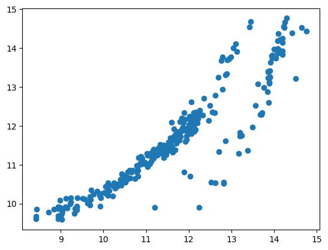

```python
plt.scatter(y_test_fit,y_LRpred_fit)
```

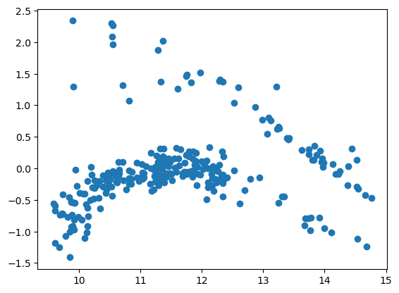

```python
#Linearity: The relationship between the dependent and independent variables is linear.
#Homoscedasticity: The variance of the errors is constant across all levels of the independent variables.
plt.scatter(y_LRpred_fit,residual)
plt.show()
```

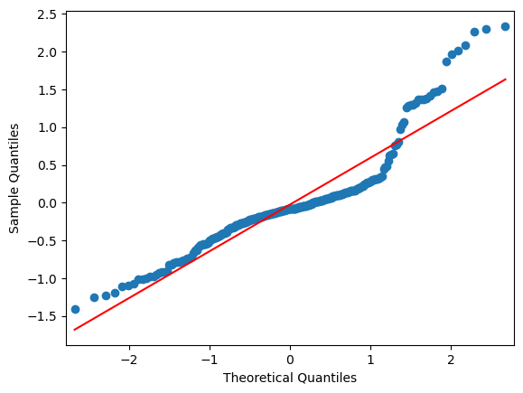

```python
#Normality: The errors follow a normal distribution.
import statsmodels.api as sm
fig = sm.qqplot(residual, line='s')
plt.show()
```

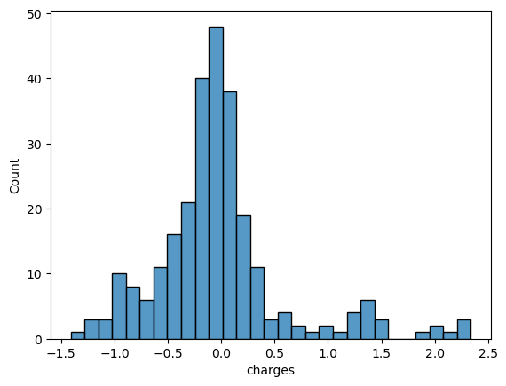

```python
sns.histplot(residual)
```

```python
#No Autocorrelation: There should be no correlation between the residual (error) terms.
```

```python
from statsmodels.stats.stattools import durbin_watson
# Using statsmodels.durbin_watson() method
DWT = durbin_watson(residual)
print(round(DWT,0))
```

```
2.0
```

DW must lie between 0 and 4.

DW = 2 — →no autocorrelation,

0 < DW < 2 — →positive autocorrelation

2 < DW < 4 — →negative autocorrelation.

```python
#No multicollinearity: The independent variables are not highly correlated with each other.
```

```python
from statsmodels.stats.outliers_influence import variance_inflation_factor

# Multicollinearity Assumption validation
vif_data = pd.DataFrame()
vif_data["feature"] = X_train_norm.columns
vif_data["VIF"] = [variance_inflation_factor(X_train_norm.values, i)for i in range(len(X_train_norm.columns))]
print(vif_data)
```

```
      feature       VIF
0         age  3.067828
1         bmi  3.744703
2    children  1.753890
3    sex_male  1.967047
4  smoker_yes  1.232881
5   region_en  2.118956
```

VIF value <= 4 then it suggests no multi-collinearity whereas a VIF value of >= 10 implies serious multi-collinearity.

The value of Durbin Watson Statistics is approximately equal to 2, hence there is "no autocorrelation".

Since all independent variables have vif values less than 4 hence there is next to "no multicollinearity".

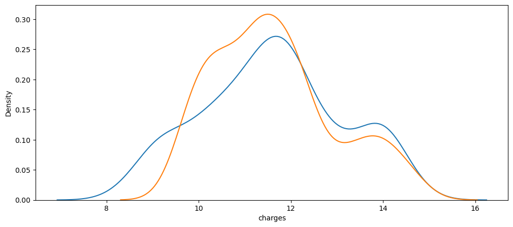

```python
plt.figure(figsize=(12,5));
ax1=sns.kdeplot(y_test_fit)
sns.kdeplot(y_LRpred_fit,ax=ax1);
```

```python
print("train_model_socre for Linear Regression",LR.score(X_train_norm,y_train_fit))
print("train_model_socre Linear Regression",LR.score(X_test_norm,y_test_fit))
```

```
train_model_socre for Linear Regression 0.7527440695515281
train_model_socre Linear Regression 0.8333558622753994
```

```python
from sklearn.metrics import mean_squared_error,mean_absolute_error,r2_score
print('R2_socre is',r2_score(y_test_fit,y_LRpred_fit))
print('mean_sqrd_error is==',mean_squared_error(y_test_fit,y_LRpred_fit))
print('mean_abs_error is==',mean_absolute_error(y_test_fit,y_LRpred_fit))
print('root_mean_squared error is==',np.sqrt(mean_squared_error(y_test_fit,y_LRpred_fit)))
adujsted_r2=1 - (1-r2_score(y_test_fit,y_LRpred_fit))*(len(y_test_fit)-1)/(len(y_test_fit)-X_test_norm.shape[1]-1)
print('adujsted_r2 is==',adujsted_r2)
```

```
R2_socre is 0.8333558622753994
mean_sqrd_error is== 0.38396814486682007
mean_abs_error is== 0.41022522226865016
root_mean_squared error is== 0.6196516318600477
adujsted_r2 is== 0.8295249625575924
```

```python
from sklearn.model_selection import cross_val_score
cross_val_results = cross_val_score(LR, X_train_norm, y_train_fit, cv=5)
print(f'Cross-Validation Results (Accuracy): {cross_val_results}')
print(f'Mean Accuracy: {cross_val_results.mean()}')
```

```
Cross-Validation Results (Accuracy): [0.6977651  0.78253588 0.74997766 0.7365113  0.78364876]
Mean Accuracy: 0.7500877379403058
```

# Lasso regression (L1 regularization)

```python
from sklearn.model_selection import GridSearchCV
from sklearn.linear_model import Lasso
param_grid = {'alpha': [0.001, 0.01, 0.1, 1, 10, 100]}  # Adjust the alpha values according to your preference
grid_search = GridSearchCV(estimator=Lasso(), param_grid=param_grid, cv=5, scoring='neg_mean_squared_error')
grid_search.fit(X_train_norm, y_train_fit)
best_alpha = grid_search.best_params_['alpha']
# Print the best hyperparameters
print("Best Alpha:", best_alpha)

lasso_model = Lasso(alpha=best_alpha,random_state=42)  # Adjust the alpha parameter according to your preference
lasso_model.fit(X_train_norm, y_train_fit)

print("train_model_socre_L1_regul",lasso_model.score(X_train_norm,y_train_fit))
print("test_model_socre_L1_regul",lasso_model.score(X_test_norm,y_test_fit))
```

```
Best Alpha: 0.001
train_model_socre_L1_regul 0.7527039234271479
test_model_socre_L1_regul 0.8327090476262338
```

# GradientBoostingRegressor

```python
from sklearn.ensemble import GradientBoostingRegressor
gbr_model = GradientBoostingRegressor(random_state=42)
gbr_model.fit(X_train_norm, y_train_fit)

print("train_model_socre_Gradient_Boosting",gbr_model.score(X_train_norm,y_train_fit))
print("test_model_socre_Gradient_Boosting",gbr_model.score(X_test_norm,y_test_fit))
```

```
train_model_socre_Gradient_Boosting 0.8759415792197579
test_model_socre_Gradient_Boosting 0.8814410485628161
```

```python
# Create a DataFrame to display the feature importances
importance_df = pd.DataFrame({'Feature': X_train_norm.columns, 'Importance': gbr_model.feature_importances_})

# Print the feature importances
print("Feature Importances:")
print(importance_df)
print(gbr_model.get_params())
```

[output not shown]

```python
y_GBrpred_fit=gbr_model.predict(X_test_norm)
#inverse Boxcox Power Transforamtion
from scipy.special import inv_boxcox
y_GBrpred = inv_boxcox(y_GBrpred_fit, y_lam)
print(y_GBrpred)
```

```
[ 9733.81060763  6582.32467894 12116.13823283 39210.49132577
  5341.16364543 10323.23080756 41436.74237221  2367.57531421
  8518.10819605 10904.45275785 13069.83818956 24768.43640333
 39801.19711065 15804.95979953  7516.2861631   8687.45808488
  3171.51368718 38174.34280761  4685.33227844  4525.02437413
  2505.3503434  20003.43691694 10097.13515634 20872.16616662
 36166.8720711   6149.49867897 39928.52131096 49499.20215718
 11114.6798267  17957.78492912  4203.8608607   9934.67488526
  1821.35589736 13967.28689486 47340.27529867 10266.76565159
  5942.47317806  5512.96973801 21259.71133033  8942.84572595
  2482.55279541 20055.92399463 40609.27628338 10360.52763841
  9168.21083688  3636.74866052  2562.53518195  8474.69243467
  4955.681084    7246.3291071   5550.18738545  6952.33594082
 23349.04874297  2099.61827678  7333.6963272   8678.96835386
 10010.76296159  4825.28501545 38633.36952699  7832.84243513
 11372.94460272  5876.93796726 13644.14589559  2006.16167103
 11809.26418414 14232.55158552  6869.6141208  22873.20787528
 16436.12227105 15380.97439803 13062.66247216  3587.76638503
  7308.76093559  3073.39744157 11413.72558925  2858.76938783
 14279.33171362  6042.26372639  9442.50292186 13227.18843193
  5261.26855809 12917.55355146 13311.39565918  8760.25163561
 26688.4566901  14899.46687162  3658.55203428  2131.26723159
  2289.22816438  2963.38463695 17484.84999228 18382.68844684
  5632.02066599  1977.52331572  2165.31101082 40775.99527336
 11199.87133232  8942.84572595  2021.60389721  9442.7340867
 13969.66787349 12983.38590758 25426.6654381  12907.4210606
 38286.16250307  2633.59203475 38444.80074987 15608.46260078
 13699.24988515  5691.59487435  6681.28106919 12514.9211154
  6880.3930433   7425.38894842  1874.19553778  2933.08091304
  2952.35193191  1664.76872671  2848.57484035 11783.54362466
 41109.20963769  5224.61113765  8233.13787337  6024.29320295
  8769.26900941  7017.80233292  5324.74615587 13969.66787349
 36972.40292945 46048.8919313  28141.71841458  9513.51431518
  2802.54633108 11644.64618982  6227.98841507  9980.85219492
 45462.93434737 19773.95098823 19261.95841175  3097.5946736
  5411.87477729  7037.04504521 42710.92956102 11504.94266485
  1595.14375402  6845.30744787  5362.58598486  8647.65517837
 42366.68815286 13134.83433877  6688.30357371  7396.24032791
  5606.02144359 13631.20436858  7279.37038635 36050.94441027
 42026.99908294 10182.25961361 10117.98768919  9734.12697314
```

[output cut: 12 more lines]

```
  3819.62136297 41119.90886005 23115.6845945   9672.40801103
  5876.58319311  7823.02599262 14627.20874794  1716.90520775
  2338.34105351  8414.41121651  9672.22068844  2865.36811741
  4036.273947   43687.84274773 44119.40802306 16422.68616061
  9901.18664726 70510.51220637 40418.94301417  9568.43149201
 36559.80415396  4702.98694501 14004.48953    37247.28480384
  5287.2127084   6244.55945112 12921.51632778 10096.7202922
 15508.30999235  1736.54106435  3346.97415194  4322.89313906
  4010.55623486  3174.57829122  4890.38363956 10270.03621942
  1882.63242972 10394.29705257  5950.23071535  7312.09400554
  2832.81712726  9241.72096414  3474.44288958 12343.81109574
 13162.68893123 14474.40355854 44714.43836083 13668.41437773
 12069.81916927  6675.73075285  8017.24482107 11269.73755845
 39317.21455342 42756.82914007 13153.10001641 13755.20753252
 14125.84171414  5626.19386008 50960.03323587 10358.53283147]
```

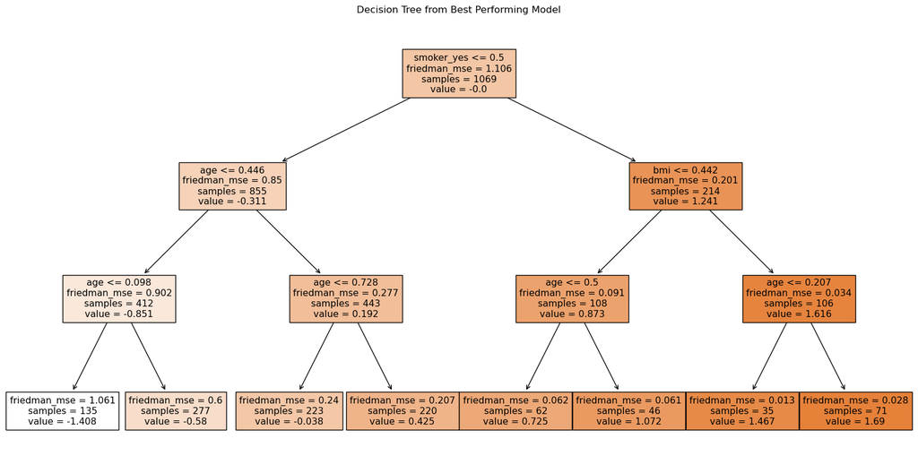

```python
from sklearn.tree import plot_tree
from sklearn.metrics import mean_squared_error

# Find the corresponding model
best_model_index = np.argmax(importance_df['Importance'])

# Plot the decision tree from the best performing model
plt.figure(figsize=(20, 10))
plot_tree(gbr_model.estimators_[best_model_index, 0], filled=True, feature_names=X_train_norm.columns)
plt.title('Decision Tree from Best Performing Model')
plt.show()
```

```python
#from pandas_profiling import ProfileReport
#profile = ProfileReport(df, title='Pandas Profiling Report', explorative=True)
```

```python
#profile.to_widgets()
```

```python
#import sweetviz as sv
#my_report = sv.analyze(df,target_feat= 'charges',pairwise_analysis= 'auto')
#my_report.show_html("df_report.html")
```